# Risk Factor Analysis

## Outcome Variable

**Outcome Variable:** ever_co

## Predictor Variables

**Intervention Variable:** perdiar24

**Adjustment Set:**

- arm
- sex
- W_mage
- meducyrs
- feducyrs
- hhwealth_quart
- hfoodsec
- hdlvry
- W_birthwt
- W_birthlen
- single
- W_nrooms
- month
- brthmon
- impfloor
- impsan
- safeh20
- delta_W_mage
- delta_meducyrs
- delta_feducyrs
- delta_hhwealth_quart
- delta_hfoodsec
- delta_hdlvry
- delta_W_birthwt
- delta_W_birthlen
- delta_single
- delta_W_nrooms
- delta_month
- delta_brthmon
- delta_impfloor
- delta_impsan
- delta_safeh20

## Stratifying Variables

The analysis was stratified on these variable(s):

- agecat
- studyid
- country

## Data Summary

| agecat | studyid | country | perdiar24 | ever_co | n_cell | n |
| --- | --- | --- | --- | --- | --- | --- |
| 0-24 months | ki0047075b-MAL-ED | BANGLADESH | 0% | 0 | 18 | 263 |
| 0-24 months | ki0047075b-MAL-ED | BANGLADESH | 0% | 1 | 2 | 263 |
| 0-24 months | ki0047075b-MAL-ED | BANGLADESH | (0%, 5%] | 0 | 125 | 263 |
| 0-24 months | ki0047075b-MAL-ED | BANGLADESH | (0%, 5%] | 1 | 23 | 263 |
| 0-24 months | ki0047075b-MAL-ED | BANGLADESH | >5% | 0 | 81 | 263 |
| 0-24 months | ki0047075b-MAL-ED | BANGLADESH | >5% | 1 | 14 | 263 |
| 0-24 months | ki0047075b-MAL-ED | BRAZIL | 0% | 0 | 130 | 233 |
| 0-24 months | ki0047075b-MAL-ED | BRAZIL | 0% | 1 | 0 | 233 |
| 0-24 months | ki0047075b-MAL-ED | BRAZIL | (0%, 5%] | 0 | 98 | 233 |
| 0-24 months | ki0047075b-MAL-ED | BRAZIL | (0%, 5%] | 1 | 3 | 233 |
| 0-24 months | ki0047075b-MAL-ED | BRAZIL | >5% | 0 | 2 | 233 |
| 0-24 months | ki0047075b-MAL-ED | BRAZIL | >5% | 1 | 0 | 233 |
| 0-24 months | ki0047075b-MAL-ED | INDIA | 0% | 0 | 13 | 251 |
| 0-24 months | ki0047075b-MAL-ED | INDIA | 0% | 1 | 1 | 251 |
| 0-24 months | ki0047075b-MAL-ED | INDIA | (0%, 5%] | 0 | 149 | 251 |
| 0-24 months | ki0047075b-MAL-ED | INDIA | (0%, 5%] | 1 | 44 | 251 |
| 0-24 months | ki0047075b-MAL-ED | INDIA | >5% | 0 | 35 | 251 |
| 0-24 months | ki0047075b-MAL-ED | INDIA | >5% | 1 | 9 | 251 |
| 0-24 months | ki0047075b-MAL-ED | NEPAL | 0% | 0 | 16 | 240 |
| 0-24 months | ki0047075b-MAL-ED | NEPAL | 0% | 1 | 1 | 240 |
| 0-24 months | ki0047075b-MAL-ED | NEPAL | (0%, 5%] | 0 | 129 | 240 |
| 0-24 months | ki0047075b-MAL-ED | NEPAL | (0%, 5%] | 1 | 15 | 240 |
| 0-24 months | ki0047075b-MAL-ED | NEPAL | >5% | 0 | 73 | 240 |
| 0-24 months | ki0047075b-MAL-ED | NEPAL | >5% | 1 | 6 | 240 |
| 0-24 months | ki0047075b-MAL-ED | PERU | 0% | 0 | 28 | 302 |
| 0-24 months | ki0047075b-MAL-ED | PERU | 0% | 1 | 0 | 302 |
| 0-24 months | ki0047075b-MAL-ED | PERU | (0%, 5%] | 0 | 108 | 302 |
| 0-24 months | ki0047075b-MAL-ED | PERU | (0%, 5%] | 1 | 5 | 302 |
| 0-24 months | ki0047075b-MAL-ED | PERU | >5% | 0 | 154 | 302 |
| 0-24 months | ki0047075b-MAL-ED | PERU | >5% | 1 | 7 | 302 |

[output cut: 270 more lines]

The following strata were considered:

- agecat: 0-24 months, studyid: ki0047075b-MAL-ED, country: BANGLADESH
- agecat: 0-24 months, studyid: ki0047075b-MAL-ED, country: BRAZIL
- agecat: 0-24 months, studyid: ki0047075b-MAL-ED, country: INDIA
- agecat: 0-24 months, studyid: ki0047075b-MAL-ED, country: NEPAL
- agecat: 0-24 months, studyid: ki0047075b-MAL-ED, country: PERU
- agecat: 0-24 months, studyid: ki0047075b-MAL-ED, country: SOUTH AFRICA
- agecat: 0-24 months, studyid: ki0047075b-MAL-ED, country: TANZANIA, UNITED REPUBLIC OF
- agecat: 0-24 months, studyid: ki1000109-EE, country: PAKISTAN
- agecat: 0-24 months, studyid: ki1000304b-SAS-FoodSuppl, country: INDIA
- agecat: 0-24 months, studyid: ki1017093-NIH-Birth, country: BANGLADESH
- agecat: 0-24 months, studyid: ki1017093b-PROVIDE, country: BANGLADESH
- agecat: 0-24 months, studyid: ki1017093c-NIH-Crypto, country: BANGLADESH
- agecat: 0-24 months, studyid: ki1112895-Guatemala BSC, country: GUATEMALA
- agecat: 0-24 months, studyid: ki1112895-iLiNS-Zinc, country: BURKINA FASO
- agecat: 0-24 months, studyid: ki1114097-CMIN, country: BANGLADESH
- agecat: 0-24 months, studyid: ki1114097-CONTENT, country: PERU
- agecat: 0-24 months, studyid: kiGH5241-JiVitA-4, country: BANGLADESH
- agecat: 0-6 months, studyid: ki0047075b-MAL-ED, country: BANGLADESH
- agecat: 0-6 months, studyid: ki0047075b-MAL-ED, country: BRAZIL
- agecat: 0-6 months, studyid: ki0047075b-MAL-ED, country: INDIA
- agecat: 0-6 months, studyid: ki0047075b-MAL-ED, country: NEPAL
- agecat: 0-6 months, studyid: ki0047075b-MAL-ED, country: PERU
- agecat: 0-6 months, studyid: ki0047075b-MAL-ED, country: SOUTH AFRICA
- agecat: 0-6 months, studyid: ki0047075b-MAL-ED, country: TANZANIA, UNITED REPUBLIC OF
- agecat: 0-6 months, studyid: ki1000109-EE, country: PAKISTAN
- agecat: 0-6 months, studyid: ki1000304b-SAS-FoodSuppl, country: INDIA
- agecat: 0-6 months, studyid: ki1017093-NIH-Birth, country: BANGLADESH
- agecat: 0-6 months, studyid: ki1017093b-PROVIDE, country: BANGLADESH
- agecat: 0-6 months, studyid: ki1017093c-NIH-Crypto, country: BANGLADESH
- agecat: 0-6 months, studyid: ki1112895-Guatemala BSC, country: GUATEMALA
- agecat: 0-6 months, studyid: ki1114097-CMIN, country: BANGLADESH
- agecat: 0-6 months, studyid: ki1114097-CONTENT, country: PERU
- agecat: 0-6 months, studyid: kiGH5241-JiVitA-4, country: BANGLADESH
- agecat: 6-24 months, studyid: ki0047075b-MAL-ED, country: BANGLADESH
- agecat: 6-24 months, studyid: ki0047075b-MAL-ED, country: BRAZIL
- agecat: 6-24 months, studyid: ki0047075b-MAL-ED, country: INDIA
- agecat: 6-24 months, studyid: ki0047075b-MAL-ED, country: NEPAL
- agecat: 6-24 months, studyid: ki0047075b-MAL-ED, country: PERU
- agecat: 6-24 months, studyid: ki0047075b-MAL-ED, country: SOUTH AFRICA
- agecat: 6-24 months, studyid: ki0047075b-MAL-ED, country: TANZANIA, UNITED REPUBLIC OF
- agecat: 6-24 months, studyid: ki1000109-EE, country: PAKISTAN
- agecat: 6-24 months, studyid: ki1000304b-SAS-FoodSuppl, country: INDIA
- agecat: 6-24 months, studyid: ki1017093-NIH-Birth, country: BANGLADESH
- agecat: 6-24 months, studyid: ki1017093b-PROVIDE, country: BANGLADESH
- agecat: 6-24 months, studyid: ki1017093c-NIH-Crypto, country: BANGLADESH
- agecat: 6-24 months, studyid: ki1112895-Guatemala BSC, country: GUATEMALA
- agecat: 6-24 months, studyid: ki1112895-iLiNS-Zinc, country: BURKINA FASO
- agecat: 6-24 months, studyid: ki1114097-CMIN, country: BANGLADESH
- agecat: 6-24 months, studyid: ki1114097-CONTENT, country: PERU
- agecat: 6-24 months, studyid: kiGH5241-JiVitA-4, country: BANGLADESH

### Dropped Strata

Some strata were dropped due to rare outcomes:

- agecat: 0-24 months, studyid: ki0047075b-MAL-ED, country: BANGLADESH
- agecat: 0-24 months, studyid: ki0047075b-MAL-ED, country: BRAZIL
- agecat: 0-24 months, studyid: ki0047075b-MAL-ED, country: INDIA
- agecat: 0-24 months, studyid: ki0047075b-MAL-ED, country: NEPAL
- agecat: 0-24 months, studyid: ki0047075b-MAL-ED, country: PERU
- agecat: 0-24 months, studyid: ki0047075b-MAL-ED, country: SOUTH AFRICA
- agecat: 0-24 months, studyid: ki0047075b-MAL-ED, country: TANZANIA, UNITED REPUBLIC OF
- agecat: 0-24 months, studyid: ki1000109-EE, country: PAKISTAN
- agecat: 0-24 months, studyid: ki1017093-NIH-Birth, country: BANGLADESH
- agecat: 0-24 months, studyid: ki1017093b-PROVIDE, country: BANGLADESH
- agecat: 0-24 months, studyid: ki1112895-Guatemala BSC, country: GUATEMALA
- agecat: 0-24 months, studyid: ki1114097-CMIN, country: BANGLADESH
- agecat: 0-24 months, studyid: ki1114097-CONTENT, country: PERU
- agecat: 0-6 months, studyid: ki0047075b-MAL-ED, country: BANGLADESH
- agecat: 0-6 months, studyid: ki0047075b-MAL-ED, country: BRAZIL
- agecat: 0-6 months, studyid: ki0047075b-MAL-ED, country: INDIA
- agecat: 0-6 months, studyid: ki0047075b-MAL-ED, country: NEPAL
- agecat: 0-6 months, studyid: ki0047075b-MAL-ED, country: PERU
- agecat: 0-6 months, studyid: ki0047075b-MAL-ED, country: SOUTH AFRICA
- agecat: 0-6 months, studyid: ki0047075b-MAL-ED, country: TANZANIA, UNITED REPUBLIC OF
- agecat: 0-6 months, studyid: ki1000109-EE, country: PAKISTAN
- agecat: 0-6 months, studyid: ki1017093-NIH-Birth, country: BANGLADESH
- agecat: 0-6 months, studyid: ki1017093b-PROVIDE, country: BANGLADESH
- agecat: 0-6 months, studyid: ki1017093c-NIH-Crypto, country: BANGLADESH
- agecat: 0-6 months, studyid: ki1112895-Guatemala BSC, country: GUATEMALA
- agecat: 0-6 months, studyid: ki1114097-CMIN, country: BANGLADESH
- agecat: 0-6 months, studyid: ki1114097-CONTENT, country: PERU
- agecat: 6-24 months, studyid: ki0047075b-MAL-ED, country: BANGLADESH
- agecat: 6-24 months, studyid: ki0047075b-MAL-ED, country: BRAZIL
- agecat: 6-24 months, studyid: ki0047075b-MAL-ED, country: INDIA
- agecat: 6-24 months, studyid: ki0047075b-MAL-ED, country: NEPAL
- agecat: 6-24 months, studyid: ki0047075b-MAL-ED, country: PERU
- agecat: 6-24 months, studyid: ki0047075b-MAL-ED, country: SOUTH AFRICA
- agecat: 6-24 months, studyid: ki0047075b-MAL-ED, country: TANZANIA, UNITED REPUBLIC OF
- agecat: 6-24 months, studyid: ki1000109-EE, country: PAKISTAN
- agecat: 6-24 months, studyid: ki1017093-NIH-Birth, country: BANGLADESH
- agecat: 6-24 months, studyid: ki1017093b-PROVIDE, country: BANGLADESH
- agecat: 6-24 months, studyid: ki1112895-Guatemala BSC, country: GUATEMALA
- agecat: 6-24 months, studyid: ki1114097-CMIN, country: BANGLADESH
- agecat: 6-24 months, studyid: ki1114097-CONTENT, country: PERU

## Methods Detail

We’re interested in the causal parameters $E[Y_a]$ for all values of $a \in \mathcal{A}$. These parameters represent the mean outcome if, possibly contrary to fact, we intervened to set all units to have $A=a$. Under the randomization and positivity assumptions, these are identified by the statistical parameters $\psi_a=E_W[E_{Y|A,W}(Y|A=a,W)]$. In addition, we’re interested in the mean of $Y$, $E[Y]$ under no intervention (the observed mean). We will estimate these parameters by using SuperLearner to fit the relevant likelihood factors – $E_{Y|A,W}(Y|A=a,W)$ and $p(A=a|W)$, and then updating our likelihood fit using a joint TMLE.

For unadjusted analyses ($W=\{\}$), initial likelihoods were estimated using Lrnr_glm to estimate the simple $E(Y|A)$ and Lrnr_mean to estimate $p(A)$. For adjusted analyses, a small library containing Lrnr_glmnet, Lrnr_xgboost, and Lrnr_mean was used.

Having estimated these parameters, we will then use the delta method to estimate relative risks and attributable risks relative to a prespecified baseline level of $A$.

# Results Detail

## Results Plots

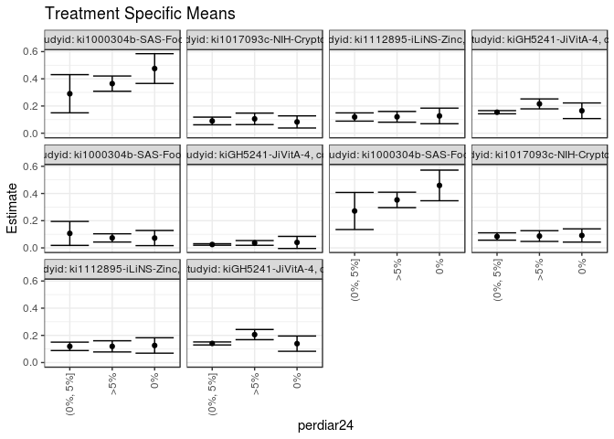

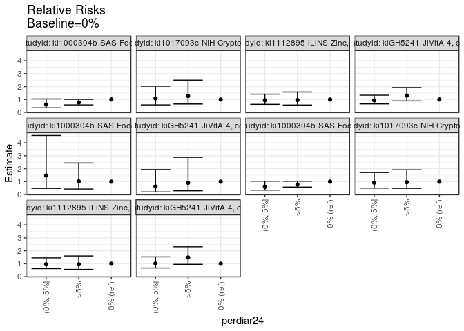

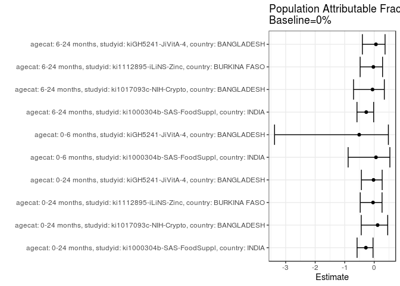

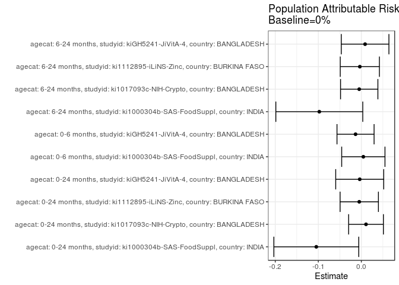

## Results Table

### Parameter: TSM

| agecat | studyid | country | intervention_level | baseline_level | estimate | ci_lower | ci_upper |
| --- | --- | --- | --- | --- | --- | --- | --- |
| 0-24 months | ki1000304b-SAS-FoodSuppl | INDIA | 0% | NA | 0.4754689 | 0.3659543 | 0.5849835 |
| 0-24 months | ki1000304b-SAS-FoodSuppl | INDIA | (0%, 5%] | NA | 0.2902714 | 0.1497237 | 0.4308191 |
| 0-24 months | ki1000304b-SAS-FoodSuppl | INDIA | >5% | NA | 0.3645887 | 0.3084578 | 0.4207196 |
| 0-24 months | ki1017093c-NIH-Crypto | BANGLADESH | 0% | NA | 0.0828168 | 0.0381294 | 0.1275042 |
| 0-24 months | ki1017093c-NIH-Crypto | BANGLADESH | (0%, 5%] | NA | 0.0900227 | 0.0617896 | 0.1182557 |
| 0-24 months | ki1017093c-NIH-Crypto | BANGLADESH | >5% | NA | 0.1055605 | 0.0632439 | 0.1478772 |
| 0-24 months | ki1112895-iLiNS-Zinc | BURKINA FASO | 0% | NA | 0.1269606 | 0.0696842 | 0.1842370 |
| 0-24 months | ki1112895-iLiNS-Zinc | BURKINA FASO | (0%, 5%] | NA | 0.1189877 | 0.0887106 | 0.1492648 |
| 0-24 months | ki1112895-iLiNS-Zinc | BURKINA FASO | >5% | NA | 0.1204710 | 0.0810661 | 0.1598759 |
| 0-24 months | kiGH5241-JiVitA-4 | BANGLADESH | 0% | NA | 0.1651135 | 0.1077841 | 0.2224430 |
| 0-24 months | kiGH5241-JiVitA-4 | BANGLADESH | (0%, 5%] | NA | 0.1543101 | 0.1425716 | 0.1660485 |
| 0-24 months | kiGH5241-JiVitA-4 | BANGLADESH | >5% | NA | 0.2155586 | 0.1789237 | 0.2521936 |
| 0-6 months | ki1000304b-SAS-FoodSuppl | INDIA | 0% | NA | 0.0722892 | 0.0165097 | 0.1280686 |
| 0-6 months | ki1000304b-SAS-FoodSuppl | INDIA | (0%, 5%] | NA | 0.1063830 | 0.0181291 | 0.1946368 |
| 0-6 months | ki1000304b-SAS-FoodSuppl | INDIA | >5% | NA | 0.0734266 | 0.0431606 | 0.1036925 |
| 0-6 months | kiGH5241-JiVitA-4 | BANGLADESH | 0% | NA | 0.0400000 | -0.0045040 | 0.0845040 |
| 0-6 months | kiGH5241-JiVitA-4 | BANGLADESH | (0%, 5%] | NA | 0.0247309 | 0.0192267 | 0.0302352 |
| 0-6 months | kiGH5241-JiVitA-4 | BANGLADESH | >5% | NA | 0.0363636 | 0.0188137 | 0.0539135 |
| 6-24 months | ki1000304b-SAS-FoodSuppl | INDIA | 0% | NA | 0.4592677 | 0.3465991 | 0.5719362 |
| 6-24 months | ki1000304b-SAS-FoodSuppl | INDIA | (0%, 5%] | NA | 0.2713420 | 0.1350622 | 0.4076219 |
| 6-24 months | ki1000304b-SAS-FoodSuppl | INDIA | >5% | NA | 0.3527819 | 0.2961694 | 0.4093944 |
| 6-24 months | ki1017093c-NIH-Crypto | BANGLADESH | 0% | NA | 0.0912357 | 0.0426630 | 0.1398084 |
| 6-24 months | ki1017093c-NIH-Crypto | BANGLADESH | (0%, 5%] | NA | 0.0837182 | 0.0567052 | 0.1107311 |
| 6-24 months | ki1017093c-NIH-Crypto | BANGLADESH | >5% | NA | 0.0870334 | 0.0475306 | 0.1265361 |
| 6-24 months | ki1112895-iLiNS-Zinc | BURKINA FASO | 0% | NA | 0.1256137 | 0.0689218 | 0.1823055 |
| 6-24 months | ki1112895-iLiNS-Zinc | BURKINA FASO | (0%, 5%] | NA | 0.1190849 | 0.0882073 | 0.1499624 |
| 6-24 months | ki1112895-iLiNS-Zinc | BURKINA FASO | >5% | NA | 0.1189961 | 0.0778394 | 0.1601527 |
| 6-24 months | kiGH5241-JiVitA-4 | BANGLADESH | 0% | NA | 0.1390185 | 0.0828569 | 0.1951801 |
| 6-24 months | kiGH5241-JiVitA-4 | BANGLADESH | (0%, 5%] | NA | 0.1405405 | 0.1295645 | 0.1515164 |
| 6-24 months | kiGH5241-JiVitA-4 | BANGLADESH | >5% | NA | 0.2057033 | 0.1682650 | 0.2431416 |

### Parameter: E(Y)

| agecat | studyid | country | intervention_level | baseline_level | estimate | ci_lower | ci_upper |
| --- | --- | --- | --- | --- | --- | --- | --- |
| 0-24 months | ki1000304b-SAS-FoodSuppl | INDIA | NA | NA | 0.3708134 | 0.3244530 | 0.4171738 |
| 0-24 months | ki1017093c-NIH-Crypto | BANGLADESH | NA | NA | 0.0936675 | 0.0729118 | 0.1144233 |
| 0-24 months | ki1112895-iLiNS-Zinc | BURKINA FASO | NA | NA | 0.1220906 | 0.0961547 | 0.1480266 |
| 0-24 months | kiGH5241-JiVitA-4 | BANGLADESH | NA | NA | 0.1613377 | 0.1500062 | 0.1726692 |
| 0-6 months | ki1000304b-SAS-FoodSuppl | INDIA | NA | NA | 0.0769231 | 0.0512858 | 0.1025603 |
| 0-6 months | kiGH5241-JiVitA-4 | BANGLADESH | NA | NA | 0.0265122 | 0.0211694 | 0.0318550 |
| 6-24 months | ki1000304b-SAS-FoodSuppl | INDIA | NA | NA | 0.3615960 | 0.3145115 | 0.4086805 |
| 6-24 months | ki1017093c-NIH-Crypto | BANGLADESH | NA | NA | 0.0863014 | 0.0659171 | 0.1066856 |
| 6-24 months | ki1112895-iLiNS-Zinc | BURKINA FASO | NA | NA | 0.1220906 | 0.0961547 | 0.1480266 |
| 6-24 months | kiGH5241-JiVitA-4 | BANGLADESH | NA | NA | 0.1477252 | 0.1371297 | 0.1583206 |

### Parameter: RR

| agecat | studyid | country | intervention_level | baseline_level | estimate | ci_lower | ci_upper |
| --- | --- | --- | --- | --- | --- | --- | --- |
| 0-24 months | ki1000304b-SAS-FoodSuppl | INDIA | 0% | 0% | 1.0000000 | 1.0000000 | 1.000000 |
| 0-24 months | ki1000304b-SAS-FoodSuppl | INDIA | (0%, 5%] | 0% | 0.6104950 | 0.3577010 | 1.041943 |
| 0-24 months | ki1000304b-SAS-FoodSuppl | INDIA | >5% | 0% | 0.7667982 | 0.5809871 | 1.012035 |
| 0-24 months | ki1017093c-NIH-Crypto | BANGLADESH | 0% | 0% | 1.0000000 | 1.0000000 | 1.000000 |
| 0-24 months | ki1017093c-NIH-Crypto | BANGLADESH | (0%, 5%] | 0% | 1.0870098 | 0.5821403 | 2.029735 |
| 0-24 months | ki1017093c-NIH-Crypto | BANGLADESH | >5% | 0% | 1.2746266 | 0.6506619 | 2.496954 |
| 0-24 months | ki1112895-iLiNS-Zinc | BURKINA FASO | 0% | 0% | 1.0000000 | 1.0000000 | 1.000000 |
| 0-24 months | ki1112895-iLiNS-Zinc | BURKINA FASO | (0%, 5%] | 0% | 0.9372020 | 0.6223246 | 1.411398 |
| 0-24 months | ki1112895-iLiNS-Zinc | BURKINA FASO | >5% | 0% | 0.9488848 | 0.5712624 | 1.576127 |
| 0-24 months | kiGH5241-JiVitA-4 | BANGLADESH | 0% | 0% | 1.0000000 | 1.0000000 | 1.000000 |
| 0-24 months | kiGH5241-JiVitA-4 | BANGLADESH | (0%, 5%] | 0% | 0.9345694 | 0.6563186 | 1.330786 |
| 0-24 months | kiGH5241-JiVitA-4 | BANGLADESH | >5% | 0% | 1.3055176 | 0.8871596 | 1.921161 |
| 0-6 months | ki1000304b-SAS-FoodSuppl | INDIA | 0% | 0% | 1.0000000 | 1.0000000 | 1.000000 |
| 0-6 months | ki1000304b-SAS-FoodSuppl | INDIA | (0%, 5%] | 0% | 1.4716312 | 0.4739794 | 4.569182 |
| 0-6 months | ki1000304b-SAS-FoodSuppl | INDIA | >5% | 0% | 1.0157343 | 0.4235009 | 2.436161 |
| 0-6 months | kiGH5241-JiVitA-4 | BANGLADESH | 0% | 0% | 1.0000000 | 1.0000000 | 1.000000 |
| 0-6 months | kiGH5241-JiVitA-4 | BANGLADESH | (0%, 5%] | 0% | 0.6182734 | 0.1981035 | 1.929607 |
| 0-6 months | kiGH5241-JiVitA-4 | BANGLADESH | >5% | 0% | 0.9090909 | 0.2868837 | 2.880771 |
| 6-24 months | ki1000304b-SAS-FoodSuppl | INDIA | 0% | 0% | 1.0000000 | 1.0000000 | 1.000000 |
| 6-24 months | ki1000304b-SAS-FoodSuppl | INDIA | (0%, 5%] | 0% | 0.5908146 | 0.3380360 | 1.032618 |
| 6-24 months | ki1000304b-SAS-FoodSuppl | INDIA | >5% | 0% | 0.7681401 | 0.5723993 | 1.030817 |
| 6-24 months | ki1017093c-NIH-Crypto | BANGLADESH | 0% | 0% | 1.0000000 | 1.0000000 | 1.000000 |
| 6-24 months | ki1017093c-NIH-Crypto | BANGLADESH | (0%, 5%] | 0% | 0.9176033 | 0.4951104 | 1.700622 |
| 6-24 months | ki1017093c-NIH-Crypto | BANGLADESH | >5% | 0% | 0.9539398 | 0.4762956 | 1.910581 |
| 6-24 months | ki1112895-iLiNS-Zinc | BURKINA FASO | 0% | 0% | 1.0000000 | 1.0000000 | 1.000000 |
| 6-24 months | ki1112895-iLiNS-Zinc | BURKINA FASO | (0%, 5%] | 0% | 0.9480247 | 0.6195532 | 1.450644 |
| 6-24 months | ki1112895-iLiNS-Zinc | BURKINA FASO | >5% | 0% | 0.9473179 | 0.5607943 | 1.600250 |
| 6-24 months | kiGH5241-JiVitA-4 | BANGLADESH | 0% | 0% | 1.0000000 | 1.0000000 | 1.000000 |
| 6-24 months | kiGH5241-JiVitA-4 | BANGLADESH | (0%, 5%] | 0% | 1.0109477 | 0.6681034 | 1.529726 |
| 6-24 months | kiGH5241-JiVitA-4 | BANGLADESH | >5% | 0% | 1.4796825 | 0.9476990 | 2.310291 |

### Parameter: PAR

| agecat | studyid | country | intervention_level | baseline_level | estimate | ci_lower | ci_upper |
| --- | --- | --- | --- | --- | --- | --- | --- |
| 0-24 months | ki1000304b-SAS-FoodSuppl | INDIA | 0% | NA | -0.1046555 | -0.2032792 | -0.0060319 |
| 0-24 months | ki1017093c-NIH-Crypto | BANGLADESH | 0% | NA | 0.0108507 | -0.0295468 | 0.0512483 |
| 0-24 months | ki1112895-iLiNS-Zinc | BURKINA FASO | 0% | NA | -0.0048699 | -0.0494019 | 0.0396620 |
| 0-24 months | kiGH5241-JiVitA-4 | BANGLADESH | 0% | NA | -0.0037758 | -0.0595451 | 0.0519935 |
| 0-6 months | ki1000304b-SAS-FoodSuppl | INDIA | 0% | NA | 0.0046339 | -0.0456361 | 0.0549039 |
| 0-6 months | kiGH5241-JiVitA-4 | BANGLADESH | 0% | NA | -0.0134878 | -0.0565735 | 0.0295979 |
| 6-24 months | ki1000304b-SAS-FoodSuppl | INDIA | 0% | NA | -0.0976716 | -0.1986359 | 0.0032926 |
| 6-24 months | ki1017093c-NIH-Crypto | BANGLADESH | 0% | NA | -0.0049343 | -0.0483013 | 0.0384326 |
| 6-24 months | ki1112895-iLiNS-Zinc | BURKINA FASO | 0% | NA | -0.0035230 | -0.0490093 | 0.0419633 |
| 6-24 months | kiGH5241-JiVitA-4 | BANGLADESH | 0% | NA | 0.0087067 | -0.0466225 | 0.0640358 |

### Parameter: PAF

| agecat | studyid | country | intervention_level | baseline_level | estimate | ci_lower | ci_upper |
| --- | --- | --- | --- | --- | --- | --- | --- |
| 0-24 months | ki1000304b-SAS-FoodSuppl | INDIA | 0% | NA | -0.2822323 | -0.5801079 | -0.0405110 |
| 0-24 months | ki1017093c-NIH-Crypto | BANGLADESH | 0% | NA | 0.1158431 | -0.4396468 | 0.4569964 |
| 0-24 months | ki1112895-iLiNS-Zinc | BURKINA FASO | 0% | NA | -0.0398879 | -0.4736627 | 0.2662047 |
| 0-24 months | kiGH5241-JiVitA-4 | BANGLADESH | 0% | NA | -0.0234031 | -0.4345332 | 0.2698992 |
| 0-6 months | ki1000304b-SAS-FoodSuppl | INDIA | 0% | NA | 0.0602410 | -0.8832383 | 0.5310487 |
| 0-6 months | kiGH5241-JiVitA-4 | BANGLADESH | 0% | NA | -0.5087407 | -3.3770372 | 0.4799453 |
| 6-24 months | ki1000304b-SAS-FoodSuppl | INDIA | 0% | NA | -0.2701126 | -0.5838518 | -0.0185208 |
| 6-24 months | ki1017093c-NIH-Crypto | BANGLADESH | 0% | NA | -0.0571756 | -0.7000286 | 0.3425873 |
| 6-24 months | ki1112895-iLiNS-Zinc | BURKINA FASO | 0% | NA | -0.0288557 | -0.4761162 | 0.2828857 |
| 6-24 months | kiGH5241-JiVitA-4 | BANGLADESH | 0% | NA | 0.0589383 | -0.4010231 | 0.3678925 |